# Design a Music Database using MySQL

SQL

ETL

Using MySQL to design a database and perform a descriptive analysis on music database.

Miftahul Hadi true  
2023-02-15

## Introduction

Hello and welcome to the MySQL personal project!

[figure not shown]

Fig. 1. MySQL Database.

In this post, I will design a database about music albums, bands, and songs. After database is created, I inserting a data on each table. Then, I address some of the SQL Query problems to get better understanding of the information.

## Preparation

Here is the preparation required to help finish the MySQL project.

### Tools

To make this project completed, I use SQL for cleaning and analysis. There are many SQL editors where you can design and manipulate a database. For this particular project, I used [MySQL Workbench](https://www.mysql.com/products/workbench/).

### Dataset

[This music dataset](https://github.com/WebDevSimplified/Learn-SQL/blob/master/data.sql) contains detailed information about bands, albums, and songs. This includes three tables that have more than 180 rows. Because the value is being inserted into the table, this dataset is ideal for designing a database from scratch.

## Design a Database

In this section, I will explain how to design a database by inserting a few tables and add a value in each column.

### Create a database

- To begin, I add and use a new database named **`record_company`** to our MySQL schema.

```sql
CREATE DATABASE record_company;
USE record_company;
```

- Because the **`record_company`** database is already in use, it will appear in the schema with bold text.

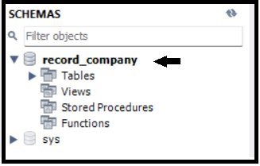

Fig. 2. New database named record_company.

### Design a table

After creating a database named `record_company`, we try to add a few tables including `bands`, `albums`, and `songs` tables. Here are the steps:

#### Bands table

```sql
CREATE TABLE bands (
  id INT NOT NULL AUTO_INCREMENT,
  name VARCHAR(255) NOT NULL,
  PRIMARY KEY (id)
);
```

#### Albums table

- After that, I add an **`albums`** table including information on albums they have produced. This includes four columns:
  - `id` to uniquely identify albums data input,
  - `name` for the album’s name,
  - `release_year` for the album’s year released,
  - `band_id` for uniquely identifying the band (*same as id on* `bands` *table*), and
  - Make the `id` of the **`albums`** table the primary key.
  - Connect `band_id` column from **`albums`** table to the `id` column from **`bands`** table.

```sql
CREATE TABLE albums (
  id INT NOT NULL AUTO_INCREMENT,
  name VARCHAR(255) NOT NULL,
  release_year INT,
  band_id INT NOT NULL,
  PRIMARY KEY (id),
  FOREIGN KEY (band_id) REFERENCES bands(id)
);
```

#### Songs table

- Lastly, add **`songs`** table including information on songs they have produced. This includes four columns:
  - `id` to uniquely identify songs data input,
  - `name` for the songs’ name,
  - `length` for the duration of the song,
  - `album_id` for uniquely identifying the album (*same as id on* `albums` *table*).
  - Make the `id` of the **`songs`** table the primary key.
  - Connect `album_id` column from **`songs`** table to the `id` column from **`albums`** table.

```sql
CREATE TABLE songs (
    id INT NOT NULL AUTO_INCREMENT,
    name VARCHAR(255) NOT NULL,
    length FLOAT NOT NULL,
    album_id INT NOT NULL,
    PRIMARY KEY (id),
    FOREIGN KEY (album_id) REFERENCES albums(id)
);
```

Because I already add three tables, it will appear in the schema like this.

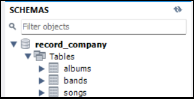

Fig. 3. A three tables appear in record_company database.

### Insert the value in the table.

After designing a few tables in the database, I insert a number of values into the table. Here, I will use an `INSERT INTO` function into `bands` table.

```sql
INSERT INTO bands(id,name) VALUES (1,'Seventh Wonder');
INSERT INTO bands(id,name) VALUES (2,'Metallica');
INSERT INTO bands(id,name) VALUES (3,'The Ocean');
INSERT INTO bands(id,name) VALUES (4,'Within Temptation');
INSERT INTO bands(id,name) VALUES (5,'Death');
INSERT INTO bands(id,name) VALUES (6,'Van Canto');
INSERT INTO bands(id,name) VALUES (7,'Dream Theater');
```

Because the dataset has a large number of rows, I will include another table [in this file](https://github.com/WebDevSimplified/Learn-SQL/blob/master/data.sql) thanks to [WebDevSimplified](https://www.youtube.com/@WebDevSimplified/about).

## SQL Query Problem

In this section, I will use some of SQL Query to answer a few question. This will helps us to get better understanding of the dataset.

### How many bands in this dataset?

**Query**

```sql
SELECT bands.name AS 'Band Name'
FROM bands;
```

Here are all the bands that included in this dataset.

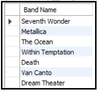

Fig. 4. All the bands included.

### Which is the oldest album?

**Query**

```sql
SELECT name AS 'Album Name', release_year FROM albums
WHERE release_year IS NOT NULL
ORDER BY release_year
LIMIT 1;
```

[output not shown]

### Which bands have released at least one album?

**Query**

```sql
SELECT DISTINCT bands.name AS 'Band Name' FROM bands
RIGHT JOIN albums ON albums.band_id = bands.id;
```

Here are the list of all bands that have released at least one album in this dataset.

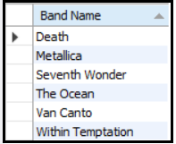

Fig. 6. The list of bands that have at least one album.

### Which bands that have no album?

**Query**

```sql
SELECT b.name AS 'Band Name' FROM bands AS b
LEFT JOIN albums AS a ON a.band_id = b.id
GROUP BY a.band_id
HAVING COUNT(a.id) = 0;
```

[output not shown]

### Longest album duration?

**Query**

```sql
SELECT a.name 'Album Name', a.release_year AS 'Release Year', SUM(s.length) AS 'Duration' FROM songs AS s
LEFT JOIN albums AS a ON s.album_id = a.id
WHERE a.release_year IS NOT NULL
GROUP BY a.id
ORDER BY SUM(s.length) DESC
LIMIT 1;
```

Here are the band with the longest album duration.

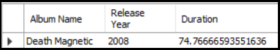

Fig. 8. The bands with the longest album.

### Update the album data with no release year

Here are the steps to updating the album data with no release year:

- First, look for albums that have no release year.

**Query**

```sql
SELECT name, release_year FROM albums
WHERE release_year IS NULL;
```

- There’s an albums with no release year (null value), update the value to 1982.

**Query**

```sql
UPDATE albums
SET release_year = 1982
WHERE release_year IS NULL;
```

- Re-check again the value that has been updated.

**Query**

```sql
SELECT name, release_year FROM albums
WHERE release_year IS NULL;
```

- Because there is **no null or empty value** in the `release_year` column, the result will be empty.

### Delete the album you updated before

- First, look for albums that have ‘1982’ in release_year column.

**Query**

```sql
SELECT id, name, release_year FROM albums
WHERE release_year = 1982;
```

- There is an album that has previously been updated; delete it with its album name using `id` column.

**Query**

```sql
DELETE FROM albums
WHERE id = 4;
```

- Re-check again the value that has been deleted.
- If there’s any problem with deleting the value, go refer to [this discussion](https://findnerd.com/list/view/ERROR-1451-23000-Cannot-delete-or-update-a-parent-row-a-foreign-key-constraint/1133/).

### Average length of all songs

**Query**

```sql
SELECT AVG(length) AS 'Average Song Duration (in min)'
FROM songs;
```

Here are the average duration of all song.

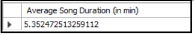

Fig. 11. The duration of all songs.

### Which song on each album is the longest?

**Query**

```sql
SELECT a.name AS 'Album Name', s.name AS 'Song Name', a.release_year AS 'Release Year', MAX(s.length) AS 'Duration' FROM albums AS a
INNER JOIN songs as s ON a.id = s.album_id
GROUP BY a.id;
```

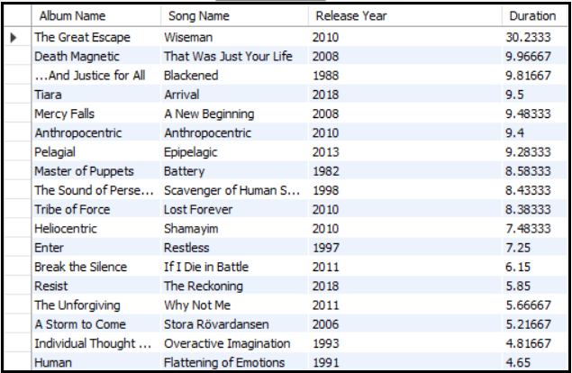

### Get the number of songs for each band

**Query**

```sql
SELECT b.name AS 'Band Name', COUNT(s.id) AS 'Number of Songs'
FROM bands AS b
JOIN albums AS a ON a.band_id = b.id
JOIN songs AS s ON s.album_id = a.id
GROUP BY b.name;
```

Here are the total songs counted for each band.

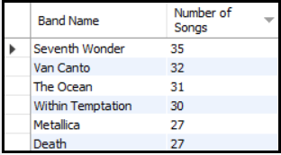

Fig. 13. Total songs of each band.

## Appendix

- WebDevSimplified [[YouTube](https://www.youtube.com/@WebDevSimplified), [GitHub](https://github.com/WebDevSimplified/Learn-SQL)]
- [Kaggle Full Script](https://www.kaggle.com/miftahulhadii)